# datamining-2020f homework1

#### iii

Use the plot() function to produce side-by-side boxplots of Outstate versus Private.

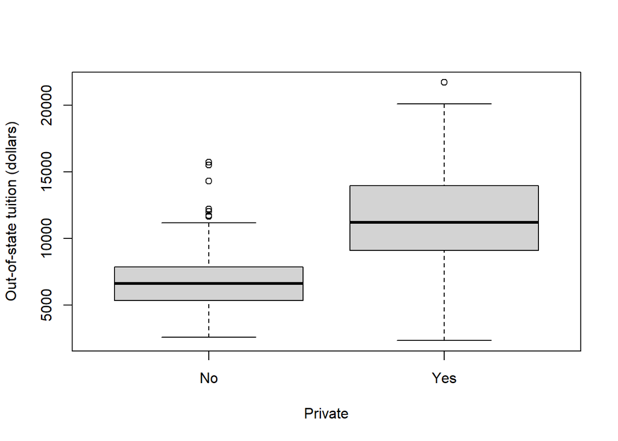

```r
# boxplots 그리기
plot(College$Private, College$Outstate, xlab = "Private", ylab = "Out-of-state tuition (dollars)")
```

#### iv.

Create a new qualitative variable, called Elite, by binning the Top10perc variable. We are going to divide universities into two groups based on whether or not the proportion of students coming from the top 10% of their high school classes exceeds 50%.

Use the summary() function to see how many elite universities there are. Now use the plot() function to produce side-by-side boxplots of Outstate versus Elite.

```r
# Top10perc인 학생 비율이 50%가 넘어가는 학교를 elite변수로 만들기
#엘리트 학교 수: 78 / 비엘리트 학교 수: 699
Elite=rep("No",nrow(College))
Elite[College$Top10perc >50]="Yes"
Elite=as.factor(Elite)
College=data.frame(College ,Elite)

summary(College$Elite)
```

```
##  No Yes
## 699  78
```

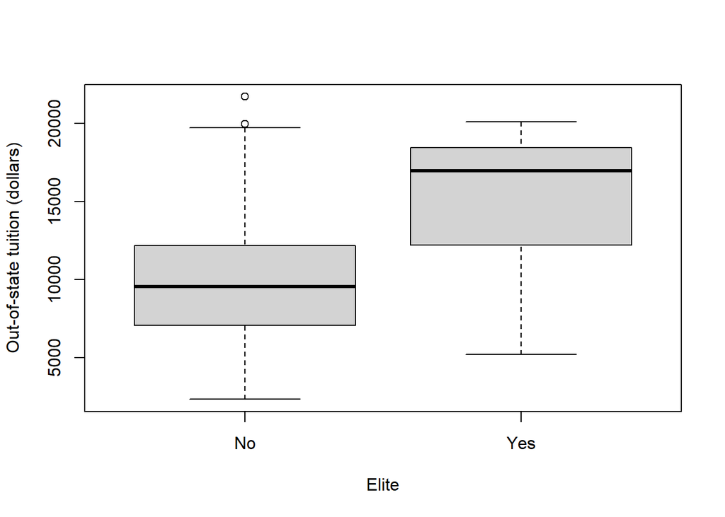

```r
#plot 그리기
plot(College$Elite, College$Outstate, xlab = "Elite", ylab = "Out-of-state tuition (dollars)")
```

#### v.

Use the hist() function to produce some histograms with differing numbers of bins for a few of the quantitative variables. You may find the command par(mfrow = c(2, 2)) useful: it will divide the print window into four regions so that four plots can be made simultaneously. Modifying the arguments to this function will divide the screen in other ways.

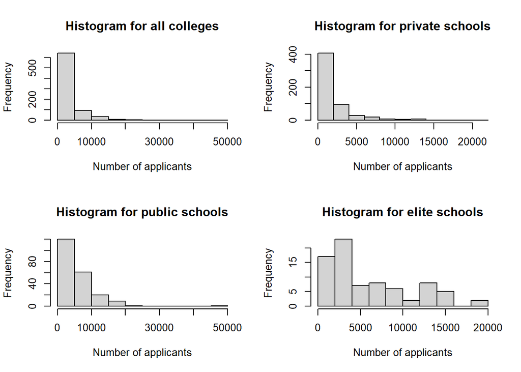

```r
#히스토그램 그리기
par(mfrow = c(2, 2))
hist(College$Apps, xlab = "Number of applicants", main = "Histogram for all colleges")
hist(College$Apps[College$Private == "Yes"], xlab = "Number of applicants", main = "Histogram for private schools")
hist(College$Apps[College$Private == "No"], xlab = "Number of applicants", main = "Histogram for public schools")
hist(College$Apps[College$Elite == "Yes"], xlab = "Number of applicants", main = "Histogram for elite schools")
```

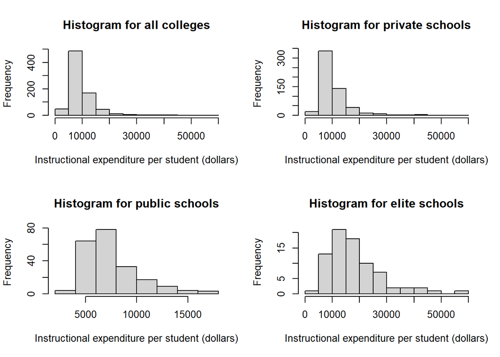

```r
par(mfrow = c(2, 2))
hist(College$Expend, xlab = "Instructional expenditure per student (dollars)", main = "Histogram for all colleges")
hist(College$Expend[College$Private == "Yes"], xlab = "Instructional expenditure per student (dollars)", main = "Histogram for private schools")
hist(College$Expend[College$Private == "No"], xlab = "Instructional expenditure per student (dollars)", main = "Histogram for public schools")
hist(College$Expend[College$Elite == "Yes"], xlab = "Instructional expenditure per student (dollars)", main = "Histogram for elite schools")
```

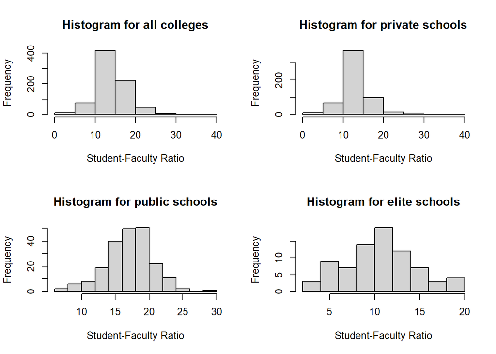

```r
par(mfrow = c(2, 2))
hist(College$S.F.Ratio, xlab = "Student-Faculty Ratio", main = "Histogram for all colleges")
hist(College$S.F.Ratio[College$Private == "Yes"], xlab = "Student-Faculty Ratio", main = "Histogram for private schools")
hist(College$S.F.Ratio[College$Private == "No"], xlab = "Student-Faculty Ratio", main = "Histogram for public schools")
hist(College$S.F.Ratio[College$Elite == "Yes"], xlab = "Student-Faculty Ratio", main = "Histogram for elite schools")
```

#### vi.

Continue exploring the data, and provide a brief summary of what you discover.

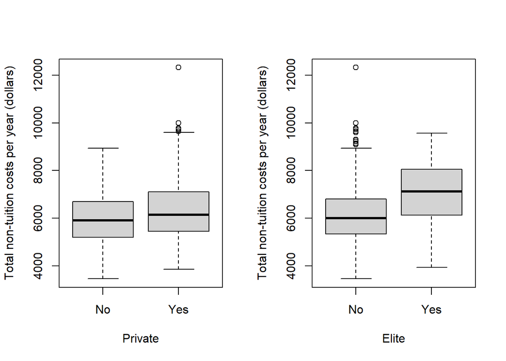

```r
NonTuitionCosts = College$Room.Board + College$Books + College$Personal
College = data.frame(College, NonTuitionCosts)
par(mfrow = c(1, 2))
plot(College$Private, College$NonTuitionCosts, xlab = "Private", ylab = "Total non-tuition costs per year (dollars)")
plot(College$Elite, College$NonTuitionCosts, xlab = "Elite", ylab = "Total non-tuition costs per year (dollars)")
```

- 왼쪽 box-plots을 보면, 사교육비가 매우 높은 일부 학교들을 제외하고는 사립학교와 공립학교 사이의 사교육 비용의 중앙값은 큰 차이가 없다.
- 그러나 오른쪽 box-plots을 보면, 엘리트 학교와 비엘리트 학교 간의 사교육비 중앙값은 차이가 있다. 엘리트 학교들이 사교육비를 더 많이 지출한다.

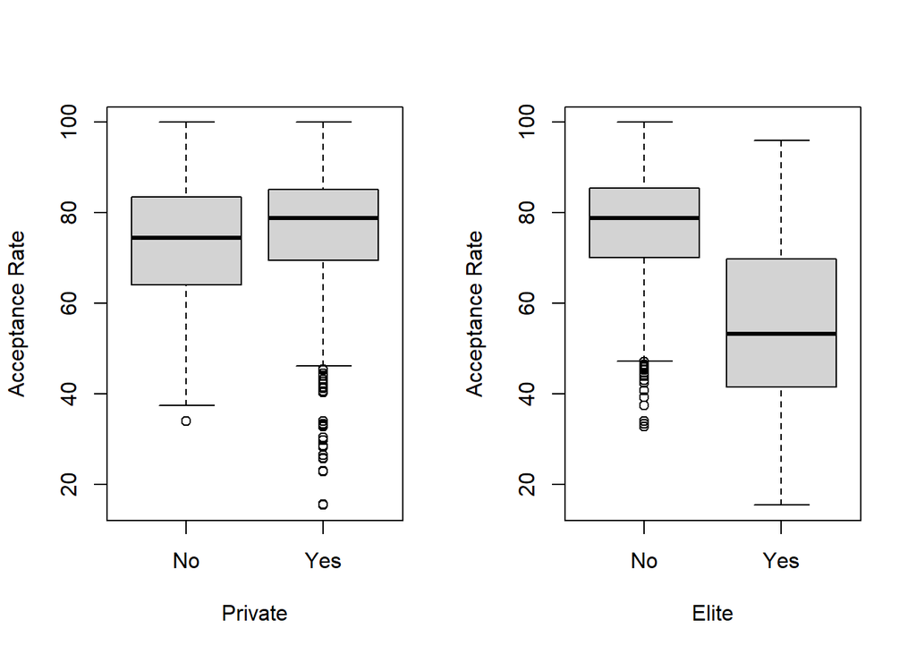

```r
AcceptPerc = College$Accept / College$Apps * 100
College = data.frame(College, AcceptPerc)
par(mfrow = c(1, 2))
plot(College$Private, College$AcceptPerc, xlab = "Private", ylab = "Acceptance Rate")
plot(College$Elite, College$AcceptPerc, xlab = "Elite", ylab = "Acceptance Rate")
```

```r
summary(College$AcceptPerc[College$Private == "Yes"])
```

```
##    Min. 1st Qu.  Median    Mean 3rd Qu.    Max.
##   15.45   69.49   78.86   75.46   85.10  100.00
```

```r
summary(College$AcceptPerc[College$Private == "No"])
```

```
##    Min. 1st Qu.  Median    Mean 3rd Qu.    Max.
##   33.97   64.12   74.43   72.65   83.42  100.00
```

```r
summary(College$AcceptPerc[College$Elite == "Yes"])
```

```
##    Min. 1st Qu.  Median    Mean 3rd Qu.    Max.
##   15.45   41.53   53.30   54.34   69.59   96.05
```

```r
summary(College$AcceptPerc[College$Elite == "No"])
```

```
##    Min. 1st Qu.  Median    Mean 3rd Qu.    Max.
##   32.83   70.13   78.81   76.96   85.48  100.00
```

- 왼쪽 box-plots은 사립학교와 공립학교의 합격률 중앙값이 75% 내외로 비슷하고 사립학교는 합격률 범위가 훨씬 넓다는 것을 보여준다(최소 15.45%, 최대 100%).
- 오른쪽 box-plots으로 엘리트 학교와 비엘리트 학교를 비교하면 엘리트 학교는 비엘리트 학교에 비해 합격률 중앙값이 낮다.(중앙값 53.3%)

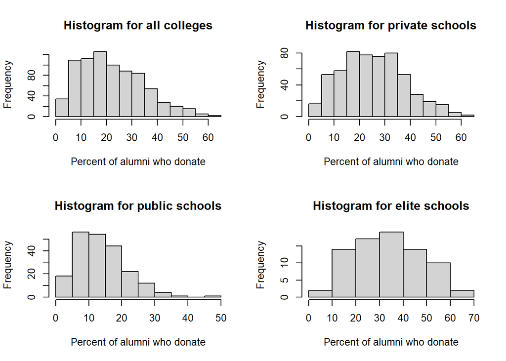

```r
par(mfrow = c(2, 2))
hist(College$perc.alumni, xlab = "Percent of alumni who donate", main = "Histogram for all colleges")
hist(College$perc.alumni[College$Private == "Yes"], xlab = "Percent of alumni who donate", main = "Histogram for private schools")
hist(College$perc.alumni[College$Private == "No"], xlab = "Percent of alumni who donate", main = "Histogram for public schools")
hist(College$perc.alumni[College$Elite == "Yes"], xlab = "Percent of alumni who donate", main = "Histogram for elite schools")
```

- histogram을 보면 사립학교와 엘리트학교일수록 기부하는 동문의 비율이 높은 편이다.

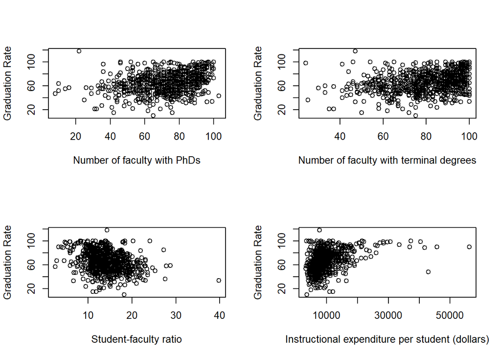

```r
par(mfrow = c(2, 2))
plot(College$PhD, College$Grad.Rate, xlab = "Number of faculty with PhDs", ylab = "Graduation Rate")
plot(College$Terminal, College$Grad.Rate, xlab = "Number of faculty with terminal degrees", ylab = "Graduation Rate")
plot(College$S.F.Ratio, College$Grad.Rate, xlab = "Student-faculty ratio", ylab = "Graduation Rate")
plot(College$Expend, College$Grad.Rate, xlab = "Instructional expenditure per student (dollars)", ylab = "Graduation Rate")
```

## ch2) 9. (풀이 : 최유나 / 기여 : 김나경)

This exercise involves the Auto data set studied in the lab. Make sure that the missing values have been removed from the data.

### (a)

Which of the predictors are quantitative, and which are qualitative?

```r
#csv파일 읽기
Auto = read.csv("./data/Auto.csv", header = TRUE, na.strings = "?")
Auto = na.omit(Auto)
summary(Auto)
```

```
##       mpg          cylinders      displacement     horsepower        weight
##  Min.   : 9.00   Min.   :3.000   Min.   : 68.0   Min.   : 46.0   Min.   :1613
##  1st Qu.:17.00   1st Qu.:4.000   1st Qu.:105.0   1st Qu.: 75.0   1st Qu.:2225
##  Median :22.75   Median :4.000   Median :151.0   Median : 93.5   Median :2804
##  Mean   :23.45   Mean   :5.472   Mean   :194.4   Mean   :104.5   Mean   :2978
##  3rd Qu.:29.00   3rd Qu.:8.000   3rd Qu.:275.8   3rd Qu.:126.0   3rd Qu.:3615
##  Max.   :46.60   Max.   :8.000   Max.   :455.0   Max.   :230.0   Max.   :5140
##   acceleration        year           origin          name
##  Min.   : 8.00   Min.   :70.00   Min.   :1.000   Length:392
##  1st Qu.:13.78   1st Qu.:73.00   1st Qu.:1.000   Class :character
##  Median :15.50   Median :76.00   Median :1.000   Mode  :character
##  Mean   :15.54   Mean   :75.98   Mean   :1.577
##  3rd Qu.:17.02   3rd Qu.:79.00   3rd Qu.:2.000
##  Max.   :24.80   Max.   :82.00   Max.   :3.000
```

```r
head(Auto)
```

```
##   mpg cylinders displacement horsepower weight acceleration year origin
## 1  18         8          307        130   3504         12.0   70      1
## 2  15         8          350        165   3693         11.5   70      1
## 3  18         8          318        150   3436         11.0   70      1
## 4  16         8          304        150   3433         12.0   70      1
## 5  17         8          302        140   3449         10.5   70      1
## 6  15         8          429        198   4341         10.0   70      1
##                        name
## 1 chevrolet chevelle malibu
## 2         buick skylark 320
## 3        plymouth satellite
## 4             amc rebel sst
## 5               ford torino
## 6          ford galaxie 500
```

Qualitative(질적 변수):

- origin - 자동차 원산지 (1. American, 2. European, 3. Japanese)
- name - 차량 이름

### (b)

What is the range of each quantitative predictor? You can answer this using the range() function.

```r
#정량적 예측 변수 범위 알아보기
?range
```

```
## starting httpd help server ... done
```

```r
range(Auto$mpg)
```

```
## [1]  9.0 46.6
```

```r
range(Auto$cylinders)
```

```
## [1] 3 8
```

```r
range(Auto$displacement)
```

```
## [1]  68 455
```

```r
range(Auto$horsepower)
```

```
## [1]  46 230
```

```r
range(Auto$weight)
```

```
## [1] 1613 5140
```

```r
range(Auto$acceleration)
```

```
## [1]  8.0 24.8
```

```r
range(Auto$year)
```

```
## [1] 70 82
```

정량적 예측 변수 범위:

- mpg = 37.6
- cylinders = 5
- displacement = 387
- horsepower = 184
- weight = 3527
- acceleration = 16.8
- year = 12

### (c)

What is the mean and standard deviation of each quantitative predictor?

```r
#평균과 표준편차 알아보기
colMeans(Auto[, 1:7])
```

```
##          mpg    cylinders displacement   horsepower       weight acceleration
##    23.445918     5.471939   194.411990   104.469388  2977.584184    15.541327
##         year
##    75.979592
```

```r
apply(Auto[, 1:7], MARGIN = 2, FUN = "sd")
```

```
##          mpg    cylinders displacement   horsepower       weight acceleration
##     7.805007     1.705783   104.644004    38.491160   849.402560     2.758864
##         year
##     3.683737
```

정량적 예측 변수의 평균 및 표준 편차:

- mpg: 평균 = 23.45, 표준편차 = 7.81
- cylinders: 평균 = 5.47, 표준편차 = 1.71
- displacement: 평균 = 194.41, 표준편차 = 104.64
- horsepower: 평균 = 104.47, 표준편차 = 38.49
- weight: 평균 = 2977.58, 표준편차 = 849.40
- acceleration: 평균 = 15.54, 표준편차 = 2.76
- year: 평균 = 75.98, 표준편차 = 3.68

### (d)

Now remove the 10th through 85th observations. What is the range, mean, and standard deviation of each predictor in the subset of the data that remains?

```r
#10~85번째 관측치 제거
apply(Auto[-(10:85), 1:7], MARGIN = 2, FUN = "range")
```

```
##       mpg cylinders displacement horsepower weight acceleration year
## [1,] 11.0         3           68         46   1649          8.5   70
## [2,] 46.6         8          455        230   4997         24.8   82
```

```r
apply(Auto[-(10:85), 1:7], MARGIN = 2, FUN = "mean")
```

```
##          mpg    cylinders displacement   horsepower       weight acceleration
##    24.404430     5.373418   187.240506   100.721519  2935.971519    15.726899
##         year
##    77.145570
```

```r
apply(Auto[-(10:85), 1:7], MARGIN = 2, FUN = "sd")
```

```
##          mpg    cylinders displacement   horsepower       weight acceleration
##     7.867283     1.654179    99.678367    35.708853   811.300208     2.693721
##         year
##     3.106217
```

- mpg: 범위 = 35.6, 평균 = 24.40, 표준편차 = 7.87
- cylinders: 범위 = 5, 평균 = 5.37, 표준편차 = 1.65
- displacement: 범위 = 387, 평균 = 187.24, 표준편차 = 99.68
- horsepower: 범위 = 184, 평균 = 100.72, 표준편차 = 35.71
- weight: 범위 = 3348, 평균 = 2935.97, 표준편차 = 811.30
- acceleration: 범위 = 16.3, 평균 = 15.73, 표준편차 = 2.69
- year: 범위=12, 평균 = 77.15, 표준편차 = 3.11

### (e)

Using the full data set, investigate the predictors graphically, using scatterplots or other tools of your choice. Create some plots highlighting the relationships among the predictors. Comment on your findings.

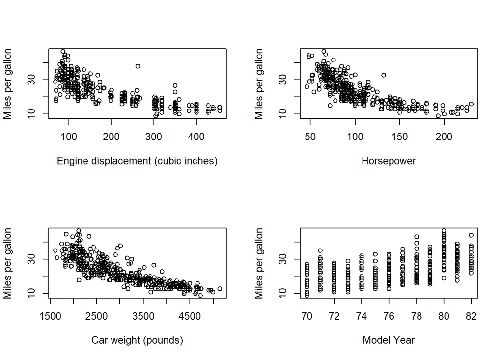

```r
#산점도 그리기
par(mfrow = c(2, 2))
plot(Auto$displacement, Auto$mpg, xlab = "Engine displacement (cubic inches)", ylab = "Miles per gallon")
plot(Auto$horsepower, Auto$mpg, xlab = "Horsepower", ylab = "Miles per gallon")
plot(Auto$weight, Auto$mpg, xlab = "Car weight (pounds)", ylab = "Miles per gallon")
plot(Auto$year, Auto$mpg, xlab = "Model Year", ylab = "Miles per gallon")
```

- 엔진 배기량/마력/자동차 중량을 증가시키면 연료 효율이 저하된다는 상관관계가 있다.

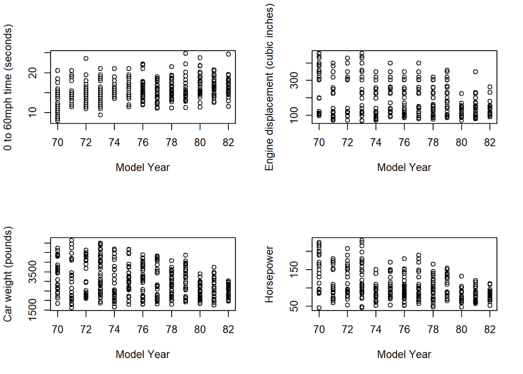

```r
#산점도 그리기
par(mfrow = c(2, 2))
plot(Auto$year, Auto$acceleration, xlab = "Model Year", ylab = "0 to 60mph time (seconds)")
plot(Auto$year, Auto$displacement, xlab = "Model Year", ylab = "Engine displacement (cubic inches)")
plot(Auto$year, Auto$weight, xlab = "Model Year", ylab = "Car weight (pounds)")
plot(Auto$year, Auto$horsepower, xlab = "Model Year", ylab = "Horsepower")
```

- 1970년부터 1982년까지 일반적으로 감소하는 최대 엔진 배기량, 자동차 중량, 마력이 약간 감소하는 것을 알 수 있다.

역사적 관점에서 보면, 이러한 변화는 1973년과 1979년 석유 파동에 대한 대응일 수 있는데, 이 때 유가 급등으로 인해 자동차 제조업체들은 자동차의 효율을 향상시키기 위한 조치를 취하게 되었다.

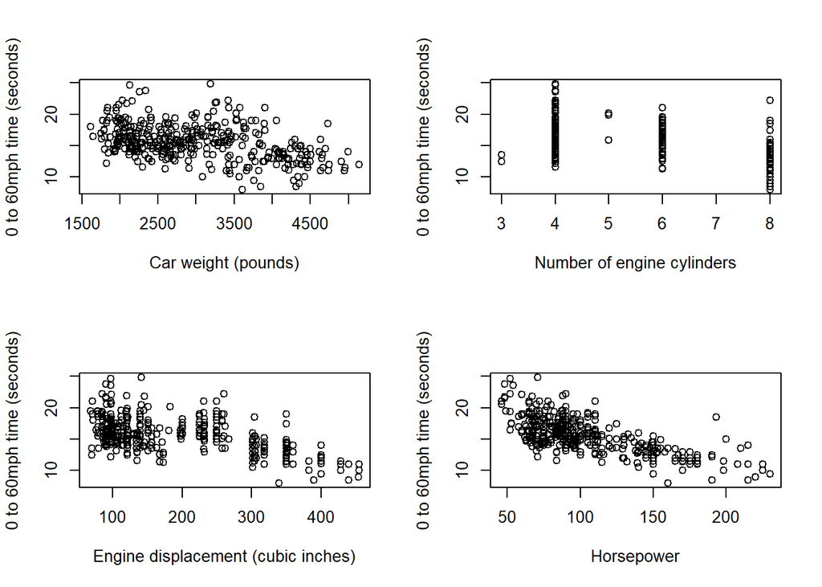

```r
par(mfrow = c(2, 2))
plot(Auto$weight, Auto$acceleration, xlab = "Car weight (pounds)", ylab = "0 to 60mph time (seconds)")
plot(Auto$cylinders, Auto$acceleration, xlab = "Number of engine cylinders", ylab = "0 to 60mph time (seconds)")
plot(Auto$displacement, Auto$acceleration, xlab = "Engine displacement (cubic inches)", ylab = "0 to 60mph time (seconds)")
plot(Auto$horsepower, Auto$acceleration, xlab = "Horsepower", ylab = "0 to 60mph time (seconds)")
```

자동차가 시속 0에서 60마일로 가속하는 데 걸리는 시간(초)과 다른 요소들 사이의 관계를 비교했다.

- 0~60시간은 엔진 변위량 증가와 마력 증가와 함께 감소한다.
- 엔진 실린더 수가 증가하면 0~60시간이 감소하는 경향이 있지만 약하다.
- 또한 자동차 중량에 따라 0~60시간도 감소하는 경향이 있다.

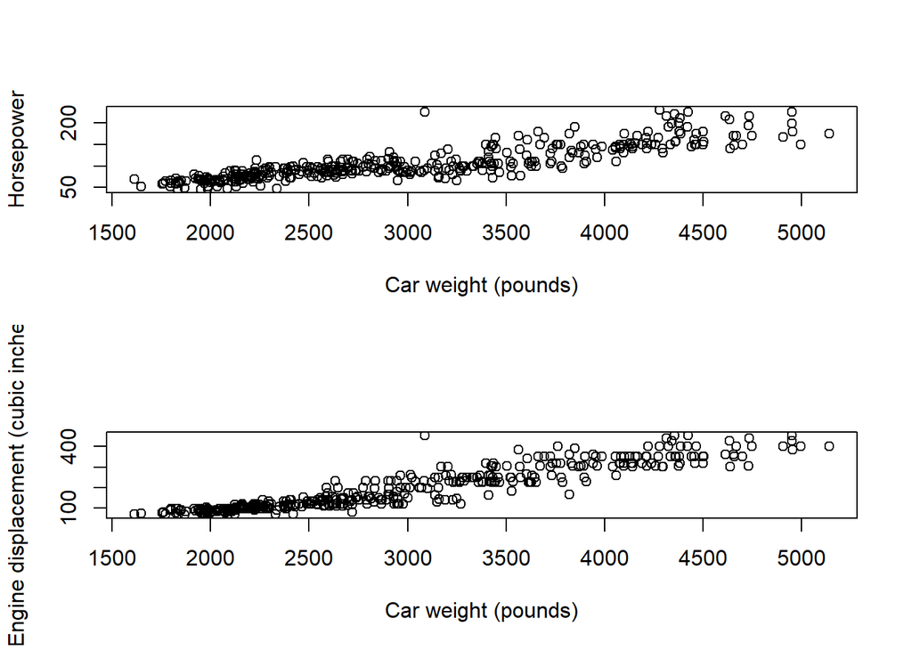

```r
par(mfrow = c(2, 1))
plot(Auto$weight, Auto$horsepower, xlab = "Car weight (pounds)", ylab = "Horsepower")
plot(Auto$weight, Auto$displacement, xlab = "Car weight (pounds)", ylab = "Engine displacement (cubic inches)")
```

- 높은 중량은 높은 마력과 높은 엔진 변위와 상관관계가 있음을 보여준다.즉, 마력과 엔진 변위가 증가할수록 차의 중량도 증가한다.

### (f)

Suppose we wish to predict gas mileage (mpg) on the basis of the other variables. Do your plots suggest that any of the other variables might be useful in predicting mpg? Justify your answer.

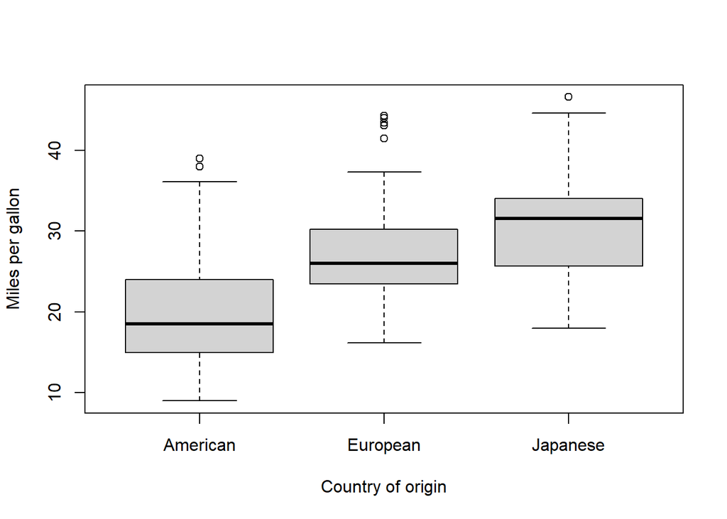

```r
Auto$origin[Auto$origin == 1] = "American"
Auto$origin[Auto$origin == 2] = "European"
Auto$origin[Auto$origin == 3] = "Japanese"
Auto$origin = as.factor(Auto$origin)

plot(Auto$origin, Auto$mpg, xlab = "Country of origin", ylab = "Miles per gallon")
```

- (e)에서 만든 산점도에 따르면, 엔진 변위, 마력, 자동차 중량을 증가시키면 연료 효율이 저하된다는 분명한 상관관계가 있기 때문에 mpg예측에 도움이 많이 될 것으로 보인다.
- 또한 위의 box-plot을 보면, 평균적으로 미국, 유럽, 일본 순으로 효율적이며 자동차의 원산지와 연비 사이에는 관계가 있음을 알 수 있다.

## ch2) 10. (풀이 : 김나경 / 기여 : 최유나)

### (a)

How many rows are in this data set? How many columns? What do the rows and columns represent?

```r
head(Boston)
```

```
##      crim zn indus chas   nox    rm  age    dis rad tax ptratio  black lstat
## 1 0.00632 18  2.31    0 0.538 6.575 65.2 4.0900   1 296    15.3 396.90  4.98
## 2 0.02731  0  7.07    0 0.469 6.421 78.9 4.9671   2 242    17.8 396.90  9.14
## 3 0.02729  0  7.07    0 0.469 7.185 61.1 4.9671   2 242    17.8 392.83  4.03
## 4 0.03237  0  2.18    0 0.458 6.998 45.8 6.0622   3 222    18.7 394.63  2.94
## 5 0.06905  0  2.18    0 0.458 7.147 54.2 6.0622   3 222    18.7 396.90  5.33
## 6 0.02985  0  2.18    0 0.458 6.430 58.7 6.0622   3 222    18.7 394.12  5.21
##   medv
## 1 24.0
## 2 21.6
## 3 34.7
## 4 33.4
## 5 36.2
## 6 28.7
```

```r
?Boston
```

Boston 데이터셋은 506행 14열로 이루어져있다.

- crim - 도시별 범죄율
- zn - 25,000 평방피트를 초과 거주지역 비율
- indus - 비소매상업지역 면적 비율
- chas - 찰스강의 경계에 위치한 경우는 1, 아니면 0
- nox - 일산화질소 농도
- rm - 주택당 방 수
- age - 1940년 이전에 건축된 주택의 비율
- dis - 직업센터의 거리
- rad - 방사형 고속도로까지의 거리
- tax - 10000달러 당 재산세율
- ptratio - 학생/교사 비율
- black - 인구 중 흑인 비율
- lstat - 인구 중 하위 계층 비율
- medv - 자가소유주택의 중간값 1000달러